# Regression Model Course Project

A.U

8/21/2020

**1.Overview/Executive Summary**

This report is based on the Coursera Regression Model Course under the given instructions. This regression analysis based on the dataset of cars which can be worked automobile industry. It is interested in exploring the relationship between the set of variables which are given in the dataset. Here, we used mtcars dataset which is located in the reshape2 R package. This project is mainly focused two questions.

1.Is an automatic or manual transmission better for MPG?

**2. Data Preprocessing**

The dataset consists of 32 observations and 11 variables.  
mpg :- Miles Per US Gallon  
cyl:- Number of Cylinders  
disp :- Displacement(cubic inches)  
hp :- Gross horsepower  
drat :- Rear axle Ratio  
wt:-weight(lb/1000)  
qsec:- ¼ mile time  
vs :- V/S  
am :- Transmission(0=automatic, 1=manual)  
gear:-Number of forward gears  
carb:-Number of carburetors

```r
head(mtcars)
```

```
                   mpg cyl disp  hp drat    wt  qsec vs am gear carb
Mazda RX4         21.0   6  160 110 3.90 2.620 16.46  0  1    4    4
Mazda RX4 Wag     21.0   6  160 110 3.90 2.875 17.02  0  1    4    4
Datsun 710        22.8   4  108  93 3.85 2.320 18.61  1  1    4    1
Hornet 4 Drive    21.4   6  258 110 3.08 3.215 19.44  1  0    3    1
Hornet Sportabout 18.7   8  360 175 3.15 3.440 17.02  0  0    3    2
Valiant           18.1   6  225 105 2.76 3.460 20.22  1  0    3    1
```

```r
str(mtcars)
```

```
'data.frame':   32 obs. of  11 variables:
 $ mpg : num  21 21 22.8 21.4 18.7 18.1 14.3 24.4 22.8 19.2 ...
 $ cyl : num  6 6 4 6 8 6 8 4 4 6 ...
 $ disp: num  160 160 108 258 360 ...
 $ hp  : num  110 110 93 110 175 105 245 62 95 123 ...
 $ drat: num  3.9 3.9 3.85 3.08 3.15 2.76 3.21 3.69 3.92 3.92 ...
 $ wt  : num  2.62 2.88 2.32 3.21 3.44 ...
 $ qsec: num  16.5 17 18.6 19.4 17 ...
 $ vs  : num  0 0 1 1 0 1 0 1 1 1 ...
 $ am  : num  1 1 1 0 0 0 0 0 0 0 ...
 $ gear: num  4 4 4 3 3 3 3 4 4 4 ...
 $ carb: num  4 4 1 1 2 1 4 2 2 4 ...
```

```r
library(tidyverse)
library(corrplot)
```

```r
df <- as.tibble(mtcars)
df
```

```
# A tibble: 32 x 11
     mpg   cyl  disp    hp  drat    wt  qsec    vs    am  gear  carb
   <dbl> <dbl> <dbl> <dbl> <dbl> <dbl> <dbl> <dbl> <dbl> <dbl> <dbl>
 1  21       6  160    110  3.9   2.62  16.5     0     1     4     4
 2  21       6  160    110  3.9   2.88  17.0     0     1     4     4
 3  22.8     4  108     93  3.85  2.32  18.6     1     1     4     1
 4  21.4     6  258    110  3.08  3.22  19.4     1     0     3     1
 5  18.7     8  360    175  3.15  3.44  17.0     0     0     3     2
 6  18.1     6  225    105  2.76  3.46  20.2     1     0     3     1
 7  14.3     8  360    245  3.21  3.57  15.8     0     0     3     4
 8  24.4     4  147.    62  3.69  3.19  20       1     0     4     2
 9  22.8     4  141.    95  3.92  3.15  22.9     1     0     4     2
10  19.2     6  168.   123  3.92  3.44  18.3     1     0     4     4
# ... with 22 more rows
```

It can be identified cyl,vs,am,gear and carb are qualitative variables but here this datasets those variables are stored as integers. So that It is necessary to convert those variables in to factors.

```r
df$cyl <- as.factor(df$cyl)
df$vs <- as.factor(df$vs)
df$gear <- as.factor(df$gear)
df$carb <- as.factor(df$carb)
df$am <- factor(df$am,labels=c('Automatic','Manual'))
str(df)
```

```
tibble [32 x 11] (S3: tbl_df/tbl/data.frame)
 $ mpg : num [1:32] 21 21 22.8 21.4 18.7 18.1 14.3 24.4 22.8 19.2 ...
 $ cyl : Factor w/ 3 levels "4","6","8": 2 2 1 2 3 2 3 1 1 2 ...
 $ disp: num [1:32] 160 160 108 258 360 ...
 $ hp  : num [1:32] 110 110 93 110 175 105 245 62 95 123 ...
 $ drat: num [1:32] 3.9 3.9 3.85 3.08 3.15 2.76 3.21 3.69 3.92 3.92 ...
 $ wt  : num [1:32] 2.62 2.88 2.32 3.21 3.44 ...
 $ qsec: num [1:32] 16.5 17 18.6 19.4 17 ...
 $ vs  : Factor w/ 2 levels "0","1": 1 1 2 2 1 2 1 2 2 2 ...
 $ am  : Factor w/ 2 levels "Automatic","Manual": 2 2 2 1 1 1 1 1 1 1 ...
 $ gear: Factor w/ 3 levels "3","4","5": 2 2 2 1 1 1 1 2 2 2 ...
 $ carb: Factor w/ 6 levels "1","2","3","4",..: 4 4 1 1 2 1 4 2 2 4 ...
```

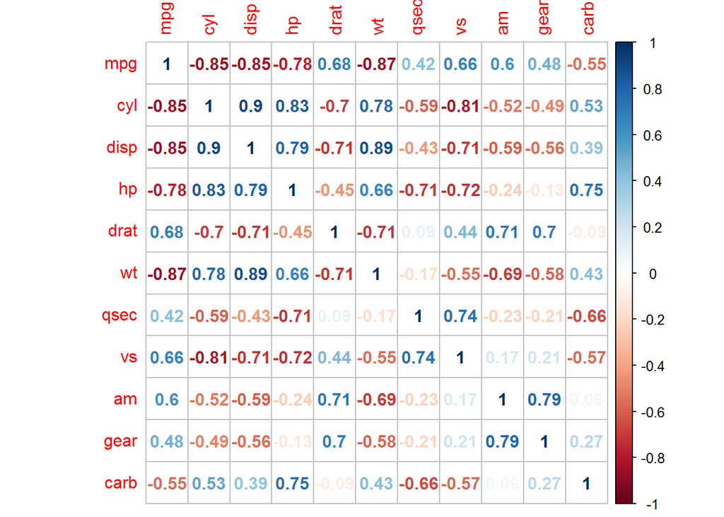

```r
M<-cor(mtcars)
corrplot(M, method="number")
```

According to this output, it can be say that cyl, disp, hp, drat, wt, vs, and am with strong linear relationship with mpg.

```r
model1 <- lm(mpg ~ factor(am), data=df)
summary(model1)
```

```
Call:
lm(formula = mpg ~ factor(am), data = df)

Residuals:
    Min      1Q  Median      3Q     Max
-9.3923 -3.0923 -0.2974  3.2439  9.5077

Coefficients:
                 Estimate Std. Error t value Pr(>|t|)
(Intercept)        17.147      1.125  15.247 1.13e-15 ***
factor(am)Manual    7.245      1.764   4.106 0.000285 ***
---
Signif. codes:  0 '***' 0.001 '**' 0.01 '*' 0.05 '.' 0.1 ' ' 1

Residual standard error: 4.902 on 30 degrees of freedom
Multiple R-squared:  0.3598,    Adjusted R-squared:  0.3385
F-statistic: 16.86 on 1 and 30 DF,  p-value: 0.000285
```

```r
anova <- aov(mpg ~ ., data = df)
summary(anova)
```

```
            Df Sum Sq Mean Sq F value   Pr(>F)
cyl          2  824.8   412.4  51.377 1.94e-07 ***
disp         1   57.6    57.6   7.181   0.0171 *
hp           1   18.5    18.5   2.305   0.1497
drat         1   11.9    11.9   1.484   0.2419
wt           1   55.8    55.8   6.950   0.0187 *
qsec         1    1.5     1.5   0.190   0.6692
vs           1    0.3     0.3   0.038   0.8488
am           1   16.6    16.6   2.064   0.1714
gear         2    5.0     2.5   0.313   0.7361
carb         5   13.6     2.7   0.339   0.8814
Residuals   15  120.4     8.0
---
Signif. codes:  0 '***' 0.001 '**' 0.01 '*' 0.05 '.' 0.1 ' ' 1
```

```r
model2 <- lm(mpg ~ cyl + disp + wt + am, data = df)
summary(model2)
```

```
Call:
lm(formula = mpg ~ cyl + disp + wt + am, data = df)

Residuals:
    Min      1Q  Median      3Q     Max
-4.5029 -1.2829 -0.4825  1.4954  5.7889

Coefficients:
             Estimate Std. Error t value Pr(>|t|)
(Intercept) 33.816067   2.914272  11.604 8.79e-12 ***
cyl6        -4.304782   1.492355  -2.885  0.00777 **
cyl8        -6.318406   2.647658  -2.386  0.02458 *
disp         0.001632   0.013757   0.119  0.90647
wt          -3.249176   1.249098  -2.601  0.01513 *
amManual     0.141212   1.326751   0.106  0.91605
---
Signif. codes:  0 '***' 0.001 '**' 0.01 '*' 0.05 '.' 0.1 ' ' 1

Residual standard error: 2.652 on 26 degrees of freedom
Multiple R-squared:  0.8376,    Adjusted R-squared:  0.8064
F-statistic: 26.82 on 5 and 26 DF,  p-value: 1.73e-09
```

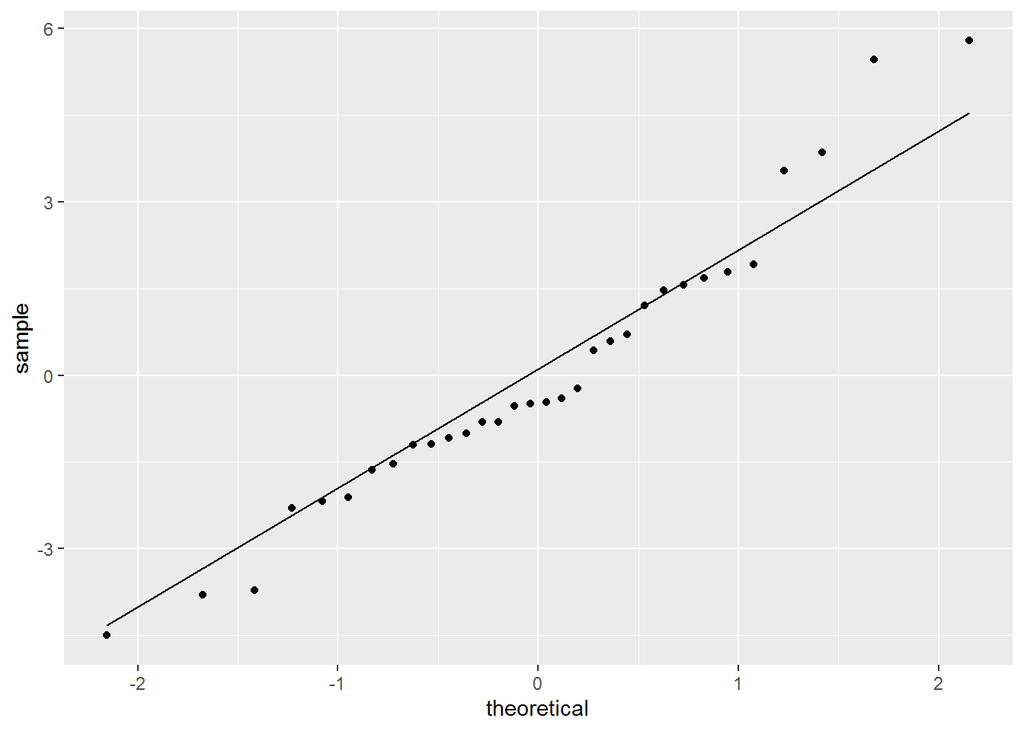

```r
ggplot(model2,aes(sample=.resid)) + stat_qq()+stat_qq_line()
```

Source of this report available at this link for verification. https://github.com/muhan1027/regressionModelReport